# ST 588 Project 1

Author

Divya Shah

## Introduction

The goal of this project is to create functions that retrieve, process, summarize, and visualize data from the Public Use Microdata Sample (PUMS) Census API. The project will use PUMS data from 2021 through 2024. The first step is to collect information about the variables that will be used later in the project.

## Part 1: Data Processing

### Parsing Variable Values

Before querying the PUMS API, I first need information about the variables used in each year of the data. The Census API provides a JSON file containing descriptions and possible values for its variables. I will create a function that retrieves this information and keeps only the variables needed for this project.

```r
library(httr)
library(jsonlite)
```

The variables needed for this project include numeric variables, categorical variables, and geographic variables. The state variable is named `ST` in 2021 and 2022 and `STATE` in 2023 and 2024, so the function accounts for this difference.

```r
get_variable_values <- function(year) {

  # Check that the requested year is valid
  if (!year %in% 2021:2024) {
    stop("Year must be 2021, 2022, 2023, or 2024.")
  }

  # Create the URL for the Census variable information
  url <- paste0(
    "https://api.census.gov/data/",
    year,
    "/acs/acs1/pums/variables.json"
  )

  # Request the JSON file
  response <- GET(url)

  # Stop if the request was not successful
  stop_for_status(response)

  # Convert the response from JSON into an R list
  variable_data <- fromJSON(
    content(response, as = "text", encoding = "UTF-8"),
    simplifyVector = FALSE
  )

  # Variables required for every year
  variables <- c(
    "AGEP",
    "GASP",
    "GRPIP",
    "JWAP",
    "JWDP",
    "JWMNP",
    "PWGTP",
    "FER",
    "HHL",
    "SCH",
    "SCHL",
    "SEX",
    "REGION",
    "DIVISION"
  )

  # State has a different variable name depending on the year
  if (year %in% c(2021, 2022)) {
    variables <- c(variables, "ST")
  } else {
    variables <- c(variables, "STATE")
  }

  # Pull out the possible values for each required variable
  variable_values <- lapply(
    variables,
    function(variable) {
      variable_data$variables[[variable]]$values
    }
  )

  # Give each list element the corresponding variable name
  names(variable_values) <- variables

  return(variable_values)
}
```

Next, I use the function for each of the four survey years.

```r
variable_values_2021 <- get_variable_values(2021)
variable_values_2022 <- get_variable_values(2022)
variable_values_2023 <- get_variable_values(2023)
variable_values_2024 <- get_variable_values(2024)
```

The four year-specific lists can then be stored together in one object. This will make it easier to access the correct set of variable values later based on the year selected by the user.

```r
variable_values <- list(
  `2021` = variable_values_2021,
  `2022` = variable_values_2022,
  `2023` = variable_values_2023,
  `2024` = variable_values_2024
)
```

I can check the names of the variables stored for 2024 to make sure the expected variables were returned.

```r
names(variable_values$`2024`)
```

```
 [1] "AGEP"     "GASP"     "GRPIP"    "JWAP"     "JWDP"     "JWMNP"
 [7] "PWGTP"    "FER"      "HHL"      "SCH"      "SCHL"     "SEX"
[13] "REGION"   "DIVISION" "STATE"
```

I can also check one categorical variable to verify that its coded values and labels were successfully parsed.

```r
variable_values$`2024`$SEX$item
```

```
$`1`
[1] "Male"

$`2`
[1] "Female"
```

The Census metadata stores variables such as `SEX` with coded values and descriptive labels, while numeric variables can contain allowable ranges.

Finally, I save the combined list as an RDS file in the project’s `data` folder. This file can be loaded later when the Census API functions need variable levels or valid geographic values.

```r
if (!dir.exists("data")) {
  dir.create("data")
}

saveRDS(
  variable_values,
  "data/variable_values.rds"
)
```

The resulting RDS file contains the variable information for all four survey years and can now be reused throughout the rest of the project without repeatedly downloading the variable descriptions.

### Parsing API Data

The next step is to retrieve data from the PUMS Census API. Before creating a more flexible function, I will first test the API using a fixed URL. This will allow me to make sure that the request works and that the returned data can be converted into a useful format.

For this initial example, I request age, person weight, and sex from the 2024 PUMS data.

```r
census_key <- Sys.getenv("CENSUS_API_KEY")

test_url <- paste0(
  "https://api.census.gov/data/2024/acs/acs1/pums",
  "?get=AGEP,PWGTP,SEX",
  "&for=state:37",
  "&SCHL=24",
  "&key=", census_key
)

test_response <- GET(test_url)

status_code(test_response)
```

```
[1] 200
```

A successful Census API request returns the data as a JSON array. The first row contains the variable names, while the remaining rows contain the observations. I will create a helper function that converts this response into a tibble.

```r
response_to_tibble <- function(response) {

  # Stop if the API request was unsuccessful
  stop_for_status(response)

  # Parse the JSON response
  api_data <- fromJSON(
    content(response, as = "text", encoding = "UTF-8")
  )

  # The first row contains the column names
  column_names <- as.character(api_data[1, ])

  # The remaining rows contain the observations
  data_values <- api_data[-1, , drop = FALSE]

  # Convert the observations to a data frame
  result <- as.data.frame(
    data_values,
    stringsAsFactors = FALSE
  )

  # Add the correct column names
  names(result) <- column_names

  # Return as a tibble
  tibble::as_tibble(result)
}
```

I can now use the helper function on the API response and inspect the first few observations.

```r
test_pums <- response_to_tibble(test_response)

head(test_pums)
```

```
# A tibble: 6 × 5
  AGEP  PWGTP SEX   SCHL  state
  <chr> <chr> <chr> <chr> <chr>
1 48    70    2     24    37
2 53    140   1     24    37
3 44    93    2     24    37
4 70    24    1     24    37
5 34    115   1     24    37
6 70    42    2     24    37
```

The API response has now been converted into a tibble with variable names as the column names. This helper function can be reused when I create a more flexible PUMS query function in the next step.

### Creating a Flexible PUMS Query Function

Now that I can successfully request data from the Census API and convert the response into a tibble, I can create a more flexible function. This function allows the user to choose the survey year, numeric variables, categorical variables, and a geographic subset.

The function also checks the inputs before making the API request. Only the years and variables required for this project are allowed. The person weight variable, `PWGTP`, must always be included along with at least one other numeric variable.

Before writing the main function, I create a few helper functions that will be useful for converting coded Census values.

```r
# Remove unnecessary leading zeros when comparing Census codes
normalize_code <- function(x) {

  x <- as.character(x)
  numeric_x <- suppressWarnings(as.numeric(x))

  result <- x

  result[!is.na(numeric_x)] <- as.character(
    numeric_x[!is.na(numeric_x)]
  )

  return(result)
}


# Convert a coded Census variable into a factor
# using the labels stored in the RDS metadata
make_factor_from_metadata <- function(x, metadata_values) {

  if (is.null(metadata_values$item)) {
    return(factor(x))
  }

  lookup <- unlist(
    metadata_values$item,
    use.names = TRUE
  )

  level_codes <- normalize_code(names(lookup))

  # Avoid duplicate levels after removing leading zeros
  keep <- !duplicated(level_codes)

  factor(
    normalize_code(x),
    levels = level_codes[keep],
    labels = unname(lookup)[keep]
  )
}
```

Two of the allowed variables, `JWAP` and `JWDP`, represent times rather than ordinary numeric measurements. Their Census codes correspond to time intervals. I use the variable descriptions saved earlier to find each interval and return the midpoint of that interval as a time value. Values that do not represent an actual time interval are returned as missing values.

```r
parse_time_midpoint <- function(x, metadata_values) {

  lookup <- unlist(
    metadata_values$item,
    use.names = TRUE
  )

  # Match codes even if leading zeros differ
  normalized_names <- normalize_code(names(lookup))

  label_lookup <- setNames(
    unname(lookup),
    normalized_names
  )

  descriptions <- unname(
    label_lookup[normalize_code(x)]
  )


  # Convert a clock time such as "10:20 a.m."
  # to seconds after midnight
  clock_to_seconds <- function(clock_text) {

    clean_text <- gsub(
      "a.m.",
      "AM",
      clock_text,
      fixed = TRUE
    )

    clean_text <- gsub(
      "p.m.",
      "PM",
      clean_text,
      fixed = TRUE
    )

    parsed_time <- strptime(
      clean_text,
      format = "%I:%M %p",
      tz = "UTC"
    )

    if (is.na(parsed_time)[1]) {
      return(NA_real_)
    }

    hour <- as.numeric(
      format(parsed_time, "%H")
    )

    minute <- as.numeric(
      format(parsed_time, "%M")
    )

    return(
      hour * 3600 + minute * 60
    )
  }


  # Find the midpoint of one Census time interval
  find_midpoint <- function(description) {

    if (
      is.na(description) ||
      !grepl(" to ", description, fixed = TRUE)
    ) {
      return(NA_real_)
    }

    time_parts <- strsplit(
      description,
      " to ",
      fixed = TRUE
    )[[1]]

    if (length(time_parts) != 2) {
      return(NA_real_)
    }

    start_seconds <- clock_to_seconds(
      time_parts[1]
    )

    end_seconds <- clock_to_seconds(
      time_parts[2]
    )

    if (
      is.na(start_seconds) ||
      is.na(end_seconds)
    ) {
      return(NA_real_)
    }

    # Account for intervals that cross midnight
    if (end_seconds < start_seconds) {
      end_seconds <- end_seconds + 24 * 60 * 60
    }

    midpoint_seconds <- (
      start_seconds + end_seconds
    ) / 2

    return(
      midpoint_seconds %% (24 * 60 * 60)
    )
  }


  midpoint_seconds <- vapply(
    descriptions,
    find_midpoint,
    numeric(1)
  )

  return(
    hms::as_hms(midpoint_seconds)
  )
}
```

I can now create the main function for querying a single year of PUMS data. The default year is 2024, the default numeric variables are `AGEP` and `PWGTP`, the default categorical variable is `SEX`, and the default geography is State.

```r
query_pums <- function(
    year = 2024,
    numeric_vars = c("AGEP", "PWGTP"),
    categorical_vars = "SEX",
    geography = "State",
    geography_value = NULL) {


  # -----------------------------
  # Check the year
  # -----------------------------

  if (
    length(year) != 1 ||
    is.na(year) ||
    !year %in% 2021:2024
  ) {
    stop(
      "Year must be one of 2021, 2022, 2023, or 2024."
    )
  }


  # -----------------------------
  # Allowed variables
  # -----------------------------

  allowed_numeric <- c(
    "AGEP",
    "GASP",
    "GRPIP",
    "JWAP",
    "JWDP",
    "JWMNP",
    "PWGTP"
  )

  allowed_categorical <- c(
    "FER",
    "HHL",
    "SCH",
    "SCHL",
    "SEX"
  )


  # -----------------------------
  # Check numeric variables
  # -----------------------------

  if (
    length(numeric_vars) < 2 ||
    !"PWGTP" %in% numeric_vars ||
    length(setdiff(numeric_vars, "PWGTP")) < 1
  ) {
    stop(
      paste(
        "Numeric variables must include PWGTP",
        "and at least one other numeric variable."
      )
    )
  }

  if (
    any(!numeric_vars %in% allowed_numeric)
  ) {
    stop(
      "An invalid numeric variable was selected."
    )
  }


  # -----------------------------
  # Check categorical variables
  # -----------------------------

  if (
    length(categorical_vars) < 1
  ) {
    stop(
      "At least one categorical variable must be selected."
    )
  }

  if (
    any(!categorical_vars %in% allowed_categorical)
  ) {
    stop(
      "An invalid categorical variable was selected."
    )
  }


  # -----------------------------
  # Check geography
  # -----------------------------

  valid_geographies <- c(
    "State",
    "Division",
    "Region"
  )

  if (
    length(geography) != 1 ||
    !geography %in% valid_geographies
  ) {
    stop(
      paste(
        "Geography must be exactly one of",
        "State, Division, or Region."
      )
    )
  }

  if (
    !is.null(geography_value) &&
    length(geography_value) != 1
  ) {
    stop(
      "Only one geography value may be supplied."
    )
  }


  # -----------------------------
  # Load variable metadata
  # -----------------------------

  variable_metadata <- readRDS(
    "data/variable_values.rds"
  )

  year_metadata <- variable_metadata[[
    as.character(year)
  ]]


  # State has a different variable name
  # in 2021/2022 and 2023/2024
  geography_variable <- switch(
    geography,

    "State" = if (
      year %in% c(2021, 2022)
    ) {
      "ST"
    } else {
      "STATE"
    },

    "Division" = "DIVISION",
    "Region" = "REGION"
  )


  geography_lookup <- unlist(
    year_metadata[[geography_variable]]$item,
    use.names = TRUE
  )

  valid_geography_codes <- names(
    geography_lookup
  )


  # -----------------------------
  # Choose default geography
  # -----------------------------

  if (is.null(geography_value)) {

    geography_value <- switch(
      geography,
      "State" = "37",
      "Division" = "5",
      "Region" = "3"
    )
  }

  geography_value <- as.character(
    geography_value
  )


  # -----------------------------
  # Handle "all"
  # -----------------------------

  if (
    tolower(geography_value) == "all"
  ) {

    api_geography_value <- "*"

  } else {

    geography_match <- match(
      normalize_code(geography_value),
      normalize_code(valid_geography_codes)
    )

    if (is.na(geography_match)) {
      stop(
        paste(
          "The selected geography value is not valid",
          "for this year and geography level."
        )
      )
    }

    # Keep the original Census code
    api_geography_value <-
      valid_geography_codes[
        geography_match
      ]
  }


  # -----------------------------
  # Variables to request
  # -----------------------------

  return_variables <- unique(
    c(
      numeric_vars,
      categorical_vars
    )
  )


  # -----------------------------
  # Census API key
  # -----------------------------

  census_key <- Sys.getenv(
    "CENSUS_API_KEY"
  )

  if (!nzchar(census_key)) {
    stop(
      paste(
        "CENSUS_API_KEY was not found.",
        "Add the key to your .Renviron file."
      )
    )
  }


  # -----------------------------
  # Create and send API request
  # -----------------------------

  base_url <- paste0(
    "https://api.census.gov/data/",
    year,
    "/acs/acs1/pums"
  )

  response <- GET(
    base_url,
    query = list(
      get = paste(
        return_variables,
        collapse = ","
      ),
      `for` = paste0(
        tolower(geography),
        ":",
        api_geography_value
      ),
      key = census_key
    )
  )


  # Convert the response into a tibble
  pums_data <- response_to_tibble(
    response
  )


  # -----------------------------
  # Convert ordinary numeric data
  # -----------------------------

  time_variables <- intersect(
    numeric_vars,
    c("JWAP", "JWDP")
  )

  ordinary_numeric <- setdiff(
    numeric_vars,
    time_variables
  )

  for (variable in ordinary_numeric) {

    pums_data[[variable]] <-
      as.numeric(
        pums_data[[variable]]
      )
  }


  # -----------------------------
  # Convert time variables
  # -----------------------------

  for (variable in time_variables) {

    pums_data[[variable]] <-
      parse_time_midpoint(
        pums_data[[variable]],
        year_metadata[[variable]]
      )
  }


  # -----------------------------
  # Convert categorical variables
  # -----------------------------

  for (variable in categorical_vars) {

    pums_data[[variable]] <-
      make_factor_from_metadata(
        pums_data[[variable]],
        year_metadata[[variable]]
      )
  }


  # -----------------------------
  # Convert geography to a factor
  # -----------------------------

  geography_column <- tolower(
    geography
  )

  pums_data[[geography_column]] <-
    make_factor_from_metadata(
      pums_data[[geography_column]],
      year_metadata[[geography_variable]]
    )


  # Rename geography column
  names(pums_data)[
    names(pums_data) == geography_column
  ] <- geography


  # -----------------------------
  # Add census class
  # -----------------------------

  class(pums_data) <- c(
    "census",
    class(pums_data)
  )

  return(pums_data)
}
```

I can test the function by requesting age, person weight, and sex for one state. I use the District of Columbia for this example because it gives a smaller data set while still testing the State geography option.

```r
single_year_example <- query_pums(
  year = 2024,
  numeric_vars = c(
    "AGEP",
    "PWGTP"
  ),
  categorical_vars = "SEX",
  geography = "State",
  geography_value = "11"
)

head(single_year_example)
```

```
# A tibble: 6 × 4
   AGEP PWGTP SEX    State
  <dbl> <dbl> <fct>  <fct>
1    18    83 Female District of Columbia/DC
2    20   147 Male   District of Columbia/DC
3    19    73 Male   District of Columbia/DC
4    19    69 Female District of Columbia/DC
5    94   126 Male   District of Columbia/DC
6    90    20 Male   District of Columbia/DC
```

```r
class(single_year_example)
```

```
[1] "census"     "tbl_df"     "tbl"        "data.frame"
```

The returned object should contain numeric age and person-weight values, labeled categorical values, and a labeled geography. It also receives the `census` class that will be used later when creating custom summary and plotting methods.

The time conversion can also be tested by requesting the departure-for-work variable, `JWDP`. Missing or non-worker values are represented as `NA`, while valid Census time intervals are converted to their midpoint.

```r
time_example <- query_pums(
  year = 2024,
  numeric_vars = c(
    "JWDP",
    "PWGTP"
  ),
  categorical_vars = "SEX",
  geography = "State",
  geography_value = "11"
)

head(
  time_example[
    !is.na(time_example$JWDP),
  ]
)
```

```
# A tibble: 6 × 4
  JWDP     PWGTP SEX    State
  <time>   <dbl> <fct>  <fct>
1 13:14:30    48 Female District of Columbia/DC
2 09:52:00    25 Male   District of Columbia/DC
3 09:02:00   138 Male   District of Columbia/DC
4 12:04:30    95 Female District of Columbia/DC
5 08:02:00    77 Female District of Columbia/DC
6 14:04:30    42 Male   District of Columbia/DC
```

### Combining Multiple Survey Years

The single-year function can now be reused to retrieve more than one survey year. Rather than repeating the entire API process, I create a second function that calls `query_pums()` once for each requested year and combines the results into one tibble. A `year` variable is included so observations from the different surveys can be identified.

```r
query_pums_years <- function(
    years,
    numeric_vars = c("AGEP", "PWGTP"),
    categorical_vars = "SEX",
    geography = "State",
    geography_value = NULL) {


  # -----------------------------
  # Check years
  # -----------------------------

  if (
    length(years) < 1 ||
    any(is.na(years)) ||
    any(!years %in% 2021:2024)
  ) {
    stop(
      paste(
        "Years must contain one or more values",
        "from 2021, 2022, 2023, and 2024."
      )
    )
  }

  years <- unique(years)


  # -----------------------------
  # Query each year
  # -----------------------------

  year_data <- lapply(
    years,
    function(current_year) {

      one_year <- query_pums(
        year = current_year,
        numeric_vars = numeric_vars,
        categorical_vars = categorical_vars,
        geography = geography,
        geography_value = geography_value
      )

      # Remove census class temporarily
      # before combining the data
      class(one_year) <- setdiff(
        class(one_year),
        "census"
      )

      one_year$year <-
        as.character(current_year)

      return(one_year)
    }
  )


  # -----------------------------
  # Combine years
  # -----------------------------

  combined_data <- do.call(
    rbind,
    year_data
  )

  combined_data <- tibble::as_tibble(
    combined_data
  )


  # Treat year as categorical
  combined_data$year <- factor(
    combined_data$year,
    levels = as.character(years)
  )


  # Add census class
  class(combined_data) <- c(
    "census",
    class(combined_data)
  )

  return(combined_data)
}
```

I can test the multiple-year function using the 2023 and 2024 surveys. The resulting data should contain observations from both years and retain the `census` class.

```r
multi_year_example <- query_pums_years(
  years = c(2023, 2024),
  numeric_vars = c(
    "AGEP",
    "PWGTP"
  ),
  categorical_vars = "SEX",
  geography = "State",
  geography_value = "11"
)

head(multi_year_example)
```

```
# A tibble: 6 × 5
   AGEP PWGTP SEX    State                   year
  <dbl> <dbl> <fct>  <fct>                   <fct>
1    75    30 Male   District of Columbia/DC 2023
2    79    29 Female District of Columbia/DC 2023
3    18    21 Female District of Columbia/DC 2023
4    19    18 Female District of Columbia/DC 2023
5    18    58 Male   District of Columbia/DC 2023
6    19    59 Female District of Columbia/DC 2023
```

```r
table(multi_year_example$year)
```

```
2023 2024
6735 6547
```

```r
class(multi_year_example)
```

```
[1] "census"     "tbl_df"     "tbl"        "data.frame"
```

The two query functions now provide a consistent way to retrieve and process PUMS data for either a single survey year or several survey years. The returned objects contain the variable types needed for later analysis and use the `census` class so that custom summary and plotting methods can be created in the next part of the project.

## Part 2: Generic Summary and Plotting Functions

### Creating a Custom Census Summary

The rows in the PUMS data do not necessarily represent one individual person. Instead, `PWGTP` gives the number of people represented by each row. Because of this, ordinary unweighted summaries would not accurately describe the population.

I will create a custom `summary()` method for objects with the `census` class. For numeric variables, the function calculates weighted means and weighted standard deviations using `PWGTP`. For categorical variables, it calculates weighted counts. Time variables are not included in the numeric summaries.

```r
summary.census <- function(
    object,
    numeric_vars = NULL,
    categorical_vars = NULL,
    ...) {


  # -----------------------------
  # Check for PWGTP
  # -----------------------------

  if (!"PWGTP" %in% names(object)) {
    stop(
      "The census object must contain PWGTP."
    )
  }


  # -----------------------------
  # Identify available variables
  # -----------------------------

  available_numeric <- names(object)[
    vapply(
      object,
      function(x) {
        is.numeric(x) &&
          !inherits(x, "hms") &&
          !inherits(x, "difftime")
      },
      logical(1)
    )
  ]

  # PWGTP is used as the weight,
  # so it is not summarized itself
  available_numeric <- setdiff(
    available_numeric,
    "PWGTP"
  )


  available_categorical <- names(object)[
    vapply(
      object,
      function(x) {
        is.factor(x) ||
          is.character(x)
      },
      logical(1)
    )
  ]


  # -----------------------------
  # Default variables
  # -----------------------------

  if (is.null(numeric_vars)) {
    numeric_vars <- available_numeric
  }

  if (is.null(categorical_vars)) {
    categorical_vars <-
      available_categorical
  }


  # -----------------------------
  # Check numeric selections
  # -----------------------------

  if (
    any(
      !numeric_vars %in%
        available_numeric
    )
  ) {
    stop(
      paste(
        "All numeric_vars must be numeric",
        "variables in the census object",
        "other than PWGTP or time variables."
      )
    )
  }


  # -----------------------------
  # Check categorical selections
  # -----------------------------

  if (
    any(
      !categorical_vars %in%
        available_categorical
    )
  ) {
    stop(
      paste(
        "All categorical_vars must be",
        "categorical variables in the census object."
      )
    )
  }


  # -----------------------------
  # Store final results
  # -----------------------------

  summary_results <- list()

  weights <- object$PWGTP


  # -----------------------------
  # Numeric summaries
  # -----------------------------

  for (variable in numeric_vars) {

    values <- object[[variable]]

    complete_rows <- (
      !is.na(values) &
      !is.na(weights)
    )

    x <- values[complete_rows]
    w <- weights[complete_rows]


    # Weighted mean
    weighted_mean <- sum(
      x * w
    ) / sum(w)


    # Weighted standard deviation
    weighted_sd <- sqrt(
      sum(
        x^2 * w
      ) / sum(w) -
        weighted_mean^2
    )


    summary_results[[variable]] <- c(
      mean = weighted_mean,
      sd = weighted_sd
    )
  }


  # -----------------------------
  # Categorical summaries
  # -----------------------------

  for (variable in categorical_vars) {

    values <- object[[variable]]

    complete_rows <- (
      !is.na(values) &
      !is.na(weights)
    )

    x <- values[complete_rows]
    w <- weights[complete_rows]


    # Remove unused factor levels
    if (is.factor(x)) {
      x <- droplevels(x)
      }
    # Weighted count for each observed level
    weighted_counts <- tapply(
      w,
      x,
      sum
      )


    summary_results[[variable]] <-
      weighted_counts
  }


  return(summary_results)
}
```

I can first test the new method using the multi-year census object created earlier. Calling the generic `summary()` function should automatically use `summary.census()` because the object has the `census` class.

```r
summary(multi_year_example)
```

```
$AGEP
    mean       sd
37.06459 21.39251

$SEX
  Male Female
653297 727925

$State
District of Columbia/DC
                1381222

$year
  2023   2024
678972 702250
```

By default, the function summarizes all ordinary numeric variables except `PWGTP` and all categorical variables in the object. In this example, `AGEP` receives a weighted mean and standard deviation, while `SEX`, `State`, and `year` receive weighted counts.

The user can also select only the variables they are interested in. For example, I can summarize age numerically and sex categorically.

```r
summary(
  multi_year_example,
  numeric_vars = "AGEP",
  categorical_vars = "SEX"
)
```

```
$AGEP
    mean       sd
37.06459 21.39251

$SEX
  Male Female
653297 727925
```

This custom method now provides population-weighted summaries for objects returned by the PUMS query functions. Using `PWGTP` ensures that rows representing more people contribute more heavily to the resulting statistics.

### Creating a Custom Census Plot

In addition to numerical summaries, I can create a custom plotting method for objects with the `census` class. The plot will compare one numeric variable across the levels of one categorical variable using a boxplot.

Because each row of the PUMS data can represent a different number of people, `PWGTP` is included as the weight in the plot.

```r
plot.census <- function(
    x,
    cat_var,
    num_var,
    ...) {


  # -----------------------------
  # Check for PWGTP
  # -----------------------------

  if (!"PWGTP" %in% names(x)) {
    stop(
      "The census object must contain PWGTP."
    )
  }


  # -----------------------------
  # Check variable names
  # -----------------------------

  if (
    length(cat_var) != 1 ||
    !cat_var %in% names(x)
  ) {
    stop(
      "cat_var must be one categorical variable in the census object."
    )
  }

  if (
    length(num_var) != 1 ||
    !num_var %in% names(x)
  ) {
    stop(
      "num_var must be one numeric variable in the census object."
    )
  }


  # -----------------------------
  # Check variable types
  # -----------------------------

  if (
    !is.factor(x[[cat_var]]) &&
    !is.character(x[[cat_var]])
  ) {
    stop(
      "cat_var must be a categorical variable."
    )
  }

  if (
    !is.numeric(x[[num_var]]) ||
    inherits(x[[num_var]], "hms") ||
    inherits(x[[num_var]], "difftime")
  ) {
    stop(
      "num_var must be an ordinary numeric variable."
    )
  }


  # -----------------------------
  # Create weighted boxplot
  # -----------------------------

  plot_object <- ggplot2::ggplot(
    x,
    ggplot2::aes(
      x = .data[[cat_var]],
      y = .data[[num_var]],
      weight = .data[["PWGTP"]]
    )
  ) +
    ggplot2::geom_boxplot(
      na.rm = TRUE
    ) +
    ggplot2::labs(
      title = paste(
        num_var,
        "by",
        cat_var
      ),
      x = cat_var,
      y = num_var
    ) +
    ggplot2::theme_minimal()

  return(plot_object)
}
```

I can test the plotting method using the multi-year census object from earlier. Since `year` is stored as a categorical variable, I can compare the age distribution between the two survey years.

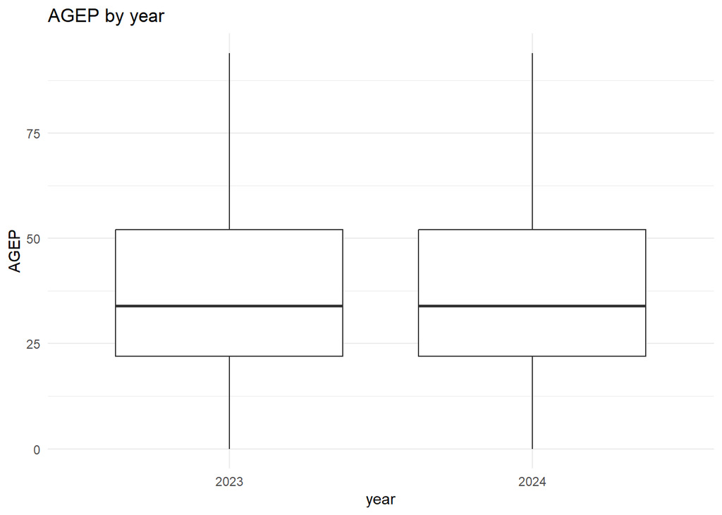

```r
plot(
  multi_year_example,
  cat_var = "year",
  num_var = "AGEP"
)
```

The custom method recognizes that the object has the `census` class and automatically uses `plot.census()`. The boxplot is weighted using `PWGTP`, so observations representing more people contribute appropriately to the plotted distributions.

## Investigation: Age Patterns in the District of Columbia

To demonstrate the functions created in this project, I will investigate age patterns in the District of Columbia from 2021 through 2024. I will compare the age distributions across survey years and between males and females.

I first use the multiple-year PUMS function to retrieve age, person weight, and sex for all four survey years.

```r
dc_investigation <- query_pums_years(
  years = 2021:2024,
  numeric_vars = c(
    "AGEP",
    "PWGTP"
  ),
  categorical_vars = "SEX",
  geography = "State",
  geography_value = "11"
)

head(dc_investigation)
```

```
# A tibble: 6 × 5
   AGEP PWGTP SEX    State                   year
  <dbl> <dbl> <fct>  <fct>                   <fct>
1    22    55 Male   District of Columbia/DC 2021
2    21   156 Male   District of Columbia/DC 2021
3    20     6 Female District of Columbia/DC 2021
4    22    28 Female District of Columbia/DC 2021
5    67    27 Male   District of Columbia/DC 2021
6    54    69 Female District of Columbia/DC 2021
```

I can begin with a weighted summary of the full data set. This gives the overall weighted mean and standard deviation of age as well as weighted population counts by sex and survey year.

```r
summary(
  dc_investigation,
  numeric_vars = "AGEP",
  categorical_vars = c(
    "SEX",
    "year"
  )
)
```

```
$AGEP
    mean       sd
37.04089 21.40869

$SEX
   Male  Female
1292330 1430745

$year
  2021   2022   2023   2024
670050 671803 678972 702250
```

To examine the years separately, I can apply the custom summary method to each individual survey year. This provides a weighted age mean and standard deviation for each year along with weighted counts by sex.

```r
investigation_years <- levels(
  dc_investigation$year
)

year_summaries <- lapply(
  investigation_years,
  function(current_year) {

    one_year <- dc_investigation[
      dc_investigation$year ==
        current_year,
    ]

    # Make sure the subset retains
    # the custom census class
    if (!"census" %in% class(one_year)) {
      class(one_year) <- c(
        "census",
        class(one_year)
      )
    }

    summary(
      one_year,
      numeric_vars = "AGEP",
      categorical_vars = "SEX"
    )
  }
)

names(year_summaries) <-
  investigation_years

year_summaries
```

```
$`2021`
$`2021`$AGEP
    mean       sd
36.97494 21.45613

$`2021`$SEX
  Male Female
319737 350313


$`2022`
$`2022`$AGEP
    mean       sd
37.05794 21.39444

$`2022`$SEX
  Male Female
319296 352507


$`2023`
$`2023`$AGEP
    mean       sd
37.10923 21.42685

$`2023`$SEX
  Male Female
320816 358156


$`2024`
$`2024`$AGEP
    mean       sd
37.02144 21.35917

$`2024`$SEX
  Male Female
332481 369769
```

The custom plotting function can also be used in multiple ways. First, I compare the weighted age distributions across the four survey years.

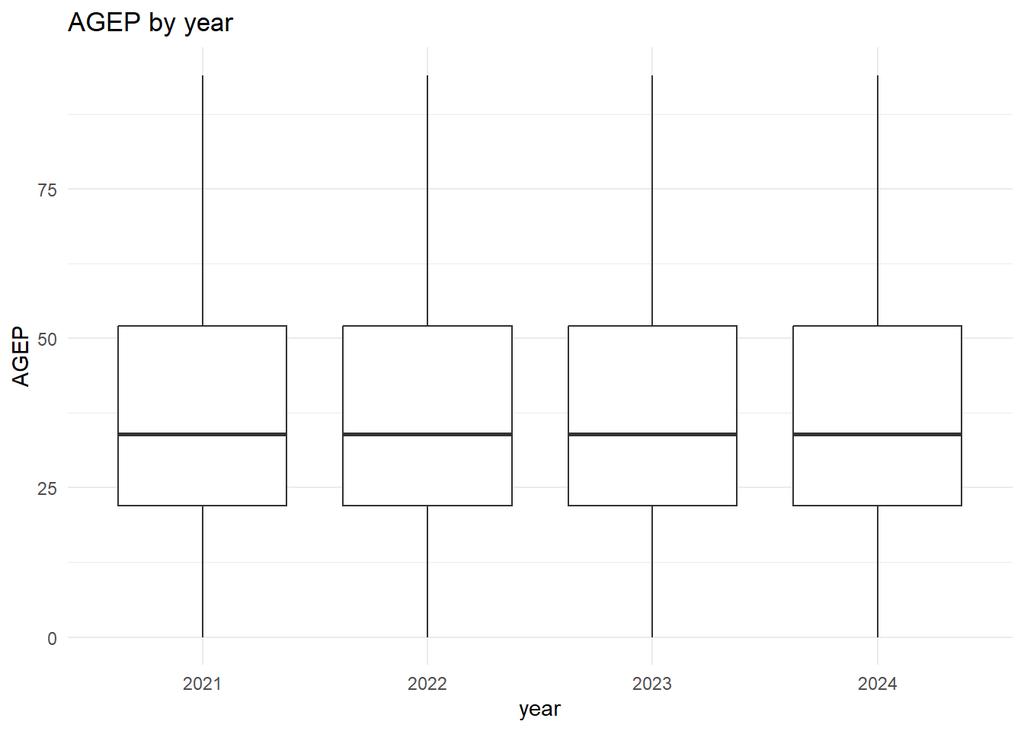

```r
plot(
  dc_investigation,
  cat_var = "year",
  num_var = "AGEP"
)
```

This plot allows the age distributions for 2021 through 2024 to be compared directly.

Next, I compare the weighted age distribution between males and females across the combined survey data.

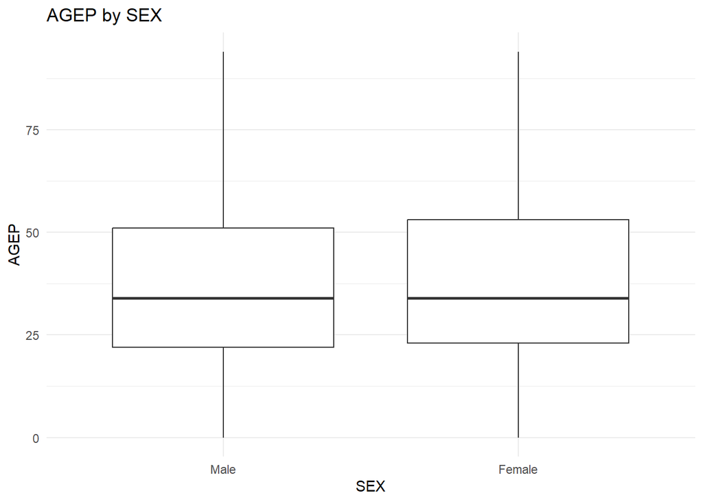

```r
plot(
  dc_investigation,
  cat_var = "SEX",
  num_var = "AGEP"
)
```

Overall, the age distribution in the District of Columbia appears very stable from 2021 through 2024. The weighted mean age stays close to 37 years in every survey year, and the yearly boxplots show very similar medians and spreads. The weighted population counts also show more females than males in each year, although the male and female age distributions are very similar. These results suggest that the overall age structure of the District of Columbia changed very little across the four survey years.